[figure not shown]

# Working with Data in the Tidyverse

MY202 · Lab 1

Jonas Weinert

Department of Methodology | London School of Economics and Political Science

1 October 2026

## Introductions

**1**Your name

**2**Your programme and year

**3**Previous experience with R, statistics, machine learning, and coding with AI tools: none is a fine answer

**4**One thing you are passionate about

## Lab overview

| Part | Topic | Functions | Data | Time |
| --- | --- | --- | --- | --- |
|  | Introductions and setup |  |  | 11 min |
| 0 | R basics | objects, functions, vectors, data frames, lists |  | 6 min |
| 1 | Summarising data | `count`, `mutate`, `group_by`, `summarise` | `agadullina2018`: 85 effect sizes, out-group entitativity and prejudice | 22 min |
| 2 | Tidy data and reshaping | `pivot_longer`, `pivot_wider` | World Bank life expectancy, 1960–2024 | 25 min |
| 3 | Iteration | `map`, `bind_rows` | `maldonado2020`: 1,268 effect sizes, age and executive functioning | 20 min |

Each part: a short demonstration, exercises in the notebook, then the solutions.

## Setup

```r
library("ggsci")
library("gt")
library("psymetadata")
library("tidyverse")
```

The notebook mixes text and **code chunks** (the grey boxes). Run a chunk with the green ▶ button, or Ctrl/Cmd + Shift + Enter. The output appears below it.

The **Functions Used** table at the top of the notebook is your reference sheet for today.

Missing package `install.packages("psymetadata")`, then run the chunk again

Conflict messages `tidyverse` reports functions it masks, such as `filter()`. These can be ignored.

# R basics

Before we start

Objects · functions · vectors · data frames · lists

## Objects, functions and packages

Setup1 · dplyr2 · tidyr3 · purrrWrap-up

```r
x <- 5          # store 5 as object x
x * 2           # returns 10

round(3.14159, digits = 2)
                # function: returns 3.14

library("dplyr")  # load a package
?round            # open the help page
```

Object A named value stored in memory. `<-` assigns: it creates or overwrites the object. Nothing is kept unless you assign it.

Function and arguments A function takes inputs, called **arguments**, inside `( )` and returns an output. Arguments can be named: `digits = 2`.

Package A collection of functions written by others. Install once with `install.packages()`, load in every session with `library()`.

## Vectors, data frames and lists

Setup1 · dplyr2 · tidyr3 · purrrWrap-up

Vector

*39.5**49.3**56.3*

`c(39.5, 49.3, 56.3)` Several values of **one type** in a sequence. `c()` combines values into a vector.

Data frame · tibble

**country****lifeexp***Niger**57.1**Honduras**69.8**Suriname**69.6*

`tibble(country = ..., lifeexp = ...)` A table. Each **column** is a vector, all of the same length. Rows are observations, columns are variables. A tibble is a data frame that prints more neatly.

List

*a data frame**a vector**another data frame*

`list(df1, x, df2)` A container whose **elements** can be any kind of object, of any length. Used in Part 3.

## Types, missing values and comparisons

Setup1 · dplyr2 · tidyr3 · purrrWrap-up

| Type | Example | Note |
| --- | --- | --- |
| numeric | `57.1` | numbers |
| character | `"Niger"` | text, always in quotes |
| logical | `TRUE`, `FALSE` | results of comparisons |
| missing | `NA` | value not available |

`"1970"` in quotes is text, not a number. `class()` tells you the type.

| Operator | Meaning | Example |
| --- | --- | --- |
| `==` | equal to | `year == 1990` |
| `!=` | not equal to | `design != "Experiment"` |
| `>` `<` | greater, less than | `n > 100` |
| `%in%` | is one of | `year %in% c(1970, 1990)` |

## `=` versus `==`

Setup1 · dplyr2 · tidyr3 · purrrWrap-up

`filter(year = 1990)`

`filter(year == 1990)`

`=` sets an argument `round(3.14159, digits = 2)`

`==` asks a question Is `year` equal to 1990? `TRUE` or `FALSE` for every row. `filter()` keeps the rows where the answer is `TRUE`.

```
Error in `filter()`:
We detected a named input.
This usually means that you've
used `=` instead of `==`.
```

# Summarising data with dplyr

Part 1

`count()` · `mutate()` · `group_by()` · `summarise()`

## Inspecting a data set

Setup1 · dplyr2 · tidyr3 · purrrWrap-up

```r
?agadullina2018          # documentation
class(agadullina2018)    # "data.frame"

agadullina2018_tbl <- as_tibble(agadullina2018)
agadullina2018_tbl       # prints 10 rows + types
glimpse(agadullina2018_tbl)
```

Data A meta-analysis: **85 effect sizes** from 21 studies on out-group entitativity and prejudice. An effect size measures the strength of a relationship on a common scale.

Key variables `yi` is the effect size (Fisher’s z), `vi` is its variance

Exam tip: never print a whole data frame. Use the tibble print or `glimpse()`.

## The pipe operator `|>`

Setup1 · dplyr2 · tidyr3 · purrrWrap-up

Nested

```r
mutate(count(agadullina2018_tbl, design),
       pct = n / sum(n) * 100)
```

Read from the inside out

Piped

```r
agadullina2018_tbl |>
  count(design) |>
  mutate(pct = n / sum(n) * 100)
```

Read top to bottom: each step passes its result to the next

Keyboard shortcut: Ctrl + Shift + M (Windows), Cmd + Shift + M (Mac).

## Core `dplyr` verbs

Setup1 · dplyr2 · tidyr3 · purrrWrap-up

count How often does each value appear?

`count(design)`

mutate Add or change a column

`mutate(pct = ...)`

summarise Collapse many rows into one

`summarise(yi = mean(yi))`

group_by Do the next step once per group

`group_by(design)`

filter · select Keep some rows · keep some columns

`filter(n > 100)`

Each verb takes a data frame as its first argument and returns a data frame.

## Grouped summaries with `group_by()`

Setup1 · dplyr2 · tidyr3 · purrrWrap-up

```r
agadullina2018_tbl |>
  summarise(yi = mean(yi))
```

| yi |
| --- |
| 0.409 |

One row for the whole data set

```r
agadullina2018_tbl |>
  group_by(design) |>
  summarise(yi = mean(yi))
```

| design | yi |
| --- | --- |
| Cross-sectional | 0.468 |
| Experiment | 0.111 |

One row per group same code, one extra line

## Exercises: Part 1

1. `?agadullina2018`: read the documentation
2. `class()`: what kind of object is it?
3. Print it (just this once)
4. `as_tibble()` with a new name, then print
5. `count()` the frequencies of `design`
6. Rewrite step 5 with a pipe `|>`
7. Pipe into `mutate()`: add a percentage column
8. `summarise()` the mean of `yi`
9. Add `group_by(design)` before `summarise()`
10. What have we found out?

Syntax you need

```r
df_tbl <- as_tibble(df)          # assign with <-

df_tbl |>
  count(design) |>               # n per group
  mutate(pct = n / sum(n) * 100) # new column

df_tbl |>
  group_by(design) |>            # per group...
  summarise(yi = mean(yi))       # ...one row each
```

**Stuck?**

- *object not found*: did you run the line with `<-`?
- *could not find function*: run the setup chunk
- Only one row? You forgot `group_by()`
- Done early? Try `glimpse()`, or `filter(n > 200)` first

## Solutions: Part 1 · Q2–4

```r
class(agadullina2018)

agadullina2018_tbl <- as_tibble(agadullina2018)
agadullina2018_tbl
```

Find out what kind of object the data is, then convert it to a tibble and look at it.

`class()` asks R what kind of object this is. `"data.frame"` means it is a table.

```
[1] "data.frame"
```

`as_tibble()` converts the data frame to a tibble, and `<-` saves it under a new name. Typing the name prints it: 85 rows and 9 columns, with each column’s type under its name.

```
# A tibble: 85 × 9
  es_id study_id authors     pub_year     n design
  <int>    <int> <chr>       <chr>    <int> <chr>
1     1        1 Agadullina… 2017       193 Cross…
2     2        1 Agadullina… 2017       193 Cross…
3     3        1 Agadullina… 2017       193 Cross…
4     4        1 Agadullina… 2017       193 Cross…
# ℹ 81 more rows
# ℹ 3 more variables: ent_alpha <dbl>, yi <dbl>,
#   vi <dbl>
```

## Solutions: Part 1 · Q5–7

```r
agadullina2018_tbl |>
  count(design) |>
  mutate(pct = (n / sum(n)) * 100)
```

Count how many effect sizes come from each study design, then express the counts as percentages.

Start with the data: one row per effect size.

```
# A tibble: 85 × 9
  es_id study_id authors     pub_year     n design
  <int>    <int> <chr>       <chr>    <int> <chr>
1     1        1 Agadullina… 2017       193 Cross…
2     2        1 Agadullina… 2017       193 Cross…
3     3        1 Agadullina… 2017       193 Cross…
4     4        1 Agadullina… 2017       193 Cross…
# ℹ 81 more rows
# ℹ 3 more variables: ent_alpha <dbl>, yi <dbl>,
#   vi <dbl>
```

`count(design)` counts the rows for each value of `design`. The result is a new, small table with the counts in a column called `n`: 71 cross-sectional, 14 experiments.

```
# A tibble: 2 × 2
  design              n
  <chr>           <int>
1 Cross-sectional    71
2 Experiment         14
```

`mutate()` adds a column. `pct` divides each count by the total and multiplies by 100: 83.5% and 16.5%.

```
# A tibble: 2 × 3
  design              n   pct
  <chr>           <int> <dbl>
1 Cross-sectional    71  83.5
2 Experiment         14  16.5
```

Q5, `count(agadullina2018_tbl, design)`, is the same as the first two lines without the pipe.

## Solutions: Part 1 · Q8–9

```r
agadullina2018_tbl |>
  group_by(design) |>
  summarise(yi = mean(yi))
```

Calculate the average effect size separately for each study design.

Start with the data: one row per effect size.

```
# A tibble: 85 × 9
  es_id study_id authors     pub_year     n design
  <int>    <int> <chr>       <chr>    <int> <chr>
1     1        1 Agadullina… 2017       193 Cross…
2     2        1 Agadullina… 2017       193 Cross…
3     3        1 Agadullina… 2017       193 Cross…
4     4        1 Agadullina… 2017       193 Cross…
# ℹ 81 more rows
# ℹ 3 more variables: ent_alpha <dbl>, yi <dbl>,
#   vi <dbl>
```

`group_by(design)` sorts the rows into groups, one per design. The data look the same: only the “Groups” line in the output shows that something changed.

```
# A tibble: 85 × 9
# Groups:   design [2]
  es_id study_id authors     pub_year     n design
  <int>    <int> <chr>       <chr>    <int> <chr>
1     1        1 Agadullina… 2017       193 Cross…
2     2        1 Agadullina… 2017       193 Cross…
3     3        1 Agadullina… 2017       193 Cross…
4     4        1 Agadullina… 2017       193 Cross…
# ℹ 81 more rows
# ℹ 3 more variables: ent_alpha <dbl>, yi <dbl>,
#   vi <dbl>
```

`summarise()` collapses each group into one row and computes the mean of `yi` within it. Cross-sectional studies average 0.468, experiments 0.111.

```
# A tibble: 2 × 2
  design             yi
  <chr>           <dbl>
1 Cross-sectional 0.468
2 Experiment      0.111
```

Q8 is the same without line 2: one row, the mean of all 85 effect sizes.

## Part 1: results

Setup1 · dplyr2 · tidyr3 · purrrWrap-up

How many effect sizes per design?

Cross-sectional**71 · 84%**

Experiment**14 · 16%**

Mean effect size (`yi`)

Cross-sectional**0.468**

Experiment**0.111**

Result 84% of effect sizes come from cross-sectional designs, which report a larger mean effect than experiments (0.468 vs 0.111)

Caveat An unweighted mean gives every effect size equal weight. Meta-analytic estimates weight by precision (`vi`), covered later in the course.

# Tidy data and reshaping

Part 2

`pivot_longer()` · `pivot_wider()` · `parse_number()`

## Tidy data

Setup1 · dplyr2 · tidyr3 · purrrWrap-up

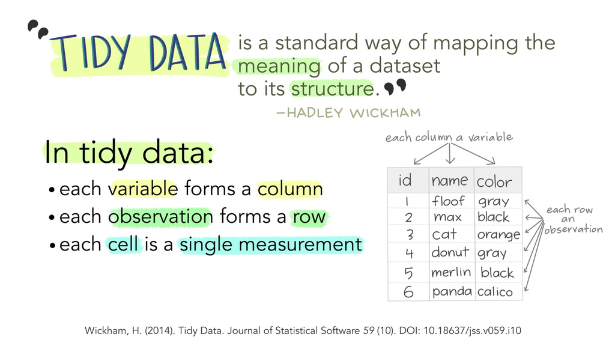

Illustration: Julia Lowndes and Allison Horst, [*Tidy Data for reproducibility, efficiency, and collaboration*](https://openscapes.org/blog/2020/10/12/tidy-data/), Openscapes blog, 2020. CC BY 4.0.

## Messy data is messy in its own way

Setup1 · dplyr2 · tidyr3 · purrrWrap-up

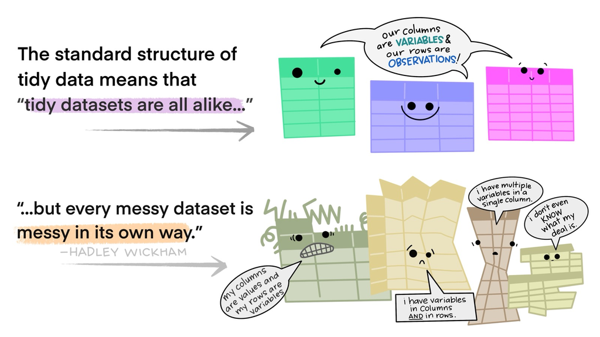

Illustration: Julia Lowndes and Allison Horst, [*Tidy Data for reproducibility, efficiency, and collaboration*](https://openscapes.org/blog/2020/10/12/tidy-data/), Openscapes blog, 2020. CC BY 4.0.

## Wide and long formats

Setup1 · dplyr2 · tidyr3 · purrrWrap-up

Wide 263 rows × 67 columns

| country_name | 1970 | 1990 | 2010 | … |
| --- | --- | --- | --- | --- |
| Burkina Faso | 39.5 | 49.3 | 56.3 | … |
| Honduras | 54.4 | 65.2 | 69.8 | … |
| Niger | 35.9 | 41.7 | 57.1 | … |

**Year** is a variable, but it’s stuck in the headers. You can’t `filter(year == 1990)`.

Long (tidy) 17,358 rows × 3 columns

| country_name | year | lifeexp |
| --- | --- | --- |
| Burkina Faso | 1970 | 39.5 |
| Burkina Faso | 1990 | 49.3 |
| Burkina Faso | 2010 | 56.3 |
| Honduras | 1970 | 54.4 |
| … | … | … |

Wide format suits presentation tables; long format suits analysis.

## Reshaping with `pivot_longer()` and `pivot_wider()`

Setup1 · dplyr2 · tidyr3 · purrrWrap-up

```r
lifeexp |>
  pivot_longer(-country_name,          # 1. which columns to stack? all but country
               names_to  = "year",     # 2. where do the old headers go?
               values_to = "lifeexp") |>  # 3. where do the numbers go?
  mutate(year = parse_number(year))    # "1970" (text) -> 1970 (number)
```

`pivot_longer()` Wide → long, for analysis

`pivot_wider()` Long → wide, for a results table: `names_from = year, values_from = lifeexp`

## Data quality issues in the World Bank file

Setup1 · dplyr2 · tidyr3 · purrrWrap-up

Aggregates

About 46 rows are regional or income-group **aggregates** (“World”, “High income”, “Euro area”).

Exclude them before averaging across countries.

Empty column

The file has a `2025` column with no values, so pivoting creates **263 rows of `NA`**.

Remove with `drop_na()` or `values_drop_na = TRUE`.

## Exercises: Part 2

Part 2 · notebook Q1–8

1. `read_csv()` the file, `rename()` column 1 to `country_name`
2. `pull()` the countries: spot the non-countries
3. `pivot_longer()` everything except `country_name`
4. `parse_number()` the `year` column
5. `filter()` four countries in 1970, 1990, 2010
6. `pivot_wider()` back to one column per year
7. `gt()` it into a formatted table
8. What have you found out?

Syntax you need

```r
lifeexp <- read_csv("data/wb-life-exp.csv") |>
  rename(country_name = 1)

lifeexp |>
  pivot_longer(-country_name, names_to = "year",
               values_to = "lifeexp") |>
  mutate(year = parse_number(year)) |>
  filter(country_name %in% c("Niger", "Honduras"),
         year %in% c(1970, 1990, 2010)) |>
  pivot_wider(names_from = year,
              values_from = lifeexp) |>
  gt()
```

**Stuck?**

- *does not exist in current working directory*: check the path. Is the CSV in a `data/` folder?
- Use `%in%` with a vector, not `==`
- A country returns nothing? Copy its exact spelling from `pull()`

## Solutions: Part 2 · Q1–2

```r
lifeexp <- read_csv("wb-life-exp.csv") |>
  rename(country_name = 1)

pull(lifeexp, country_name) |>
  head(12)
```

Load the World Bank file, give the first column a usable name, and check which rows it contains.

`read_csv()` reads the file into a tibble. The first column is called `Country Name`, with a space, which is awkward to use in code.

```
# A tibble: 263 × 67
  `Country Name`       `1960` `1961` `1962` `1963`
  <chr>                 <dbl>  <dbl>  <dbl>  <dbl>
1 Aruba                  64.0   64.2   64.6   64.9
2 Africa Eastern and …   44.2   44.5   44.9   45.2
3 Afghanistan            32.8   33.3   33.8   34.2
4 Africa Western and …   37.8   38.1   38.7   38.9
# ℹ 259 more rows
# ℹ 62 more variables: `1964` <dbl>,
#   `1965` <dbl>, `1966` <dbl>, `1967` <dbl>, …
```

`rename()` takes `new name = old column`; here the old column is given by its position, 1. `<-` saves the result as `lifeexp`.

```
# A tibble: 263 × 67
  country_name  `1960` `1961` `1962` `1963` `1964`
  <chr>          <dbl>  <dbl>  <dbl>  <dbl>  <dbl>
1 Aruba           64.0   64.2   64.6   64.9   65.3
2 Africa Easte…   44.2   44.5   44.9   45.2   45.5
3 Afghanistan     32.8   33.3   33.8   34.2   34.7
4 Africa Weste…   37.8   38.1   38.7   38.9   39.2
# ℹ 259 more rows
# ℹ 61 more variables: `1965` <dbl>,
#   `1966` <dbl>, `1967` <dbl>, `1968` <dbl>, …
```

`pull()` extracts one column as a vector, and `head(12)` keeps the first 12 values. Some are regions, such as “Arab World”: not every row is a country.

```
 [1] "Aruba"
 [2] "Africa Eastern and Southern"
 [3] "Afghanistan"
 [4] "Africa Western and Central"
 [5] "Angola"
 [6] "Albania"
 [7] "Andorra"
 [8] "Arab World"
 [9] "United Arab Emirates"
[10] "Argentina"
[11] "Armenia"
[12] "American Samoa"
```

The path assumes the CSV sits next to the notebook. `head(12)` shortens the list of 263 names for the slide.

## Solutions: Part 2 · Q3–7

```r
lifeexp |>
  pivot_longer(-country_name,
               names_to = "year",
               values_to = "lifeexp") |>
  mutate(year = parse_number(year),
         lifeexp = round(lifeexp, 1)) |>
  filter(country_name %in% c("Burkina Faso",
           "Honduras", "Niger", "Suriname"),
         year %in% c(1970, 1990, 2010)) |>
  pivot_wider(id_cols = country_name,
              names_from = year,
              values_from = lifeexp) |>
  gt()
```

Reshape the table from wide to long, keep four countries and three years, then present them as a table.

The wide table: one row per country, one column per year.

```
# A tibble: 263 × 67
  country_name  `1960` `1961` `1962` `1963` `1964`
  <chr>          <dbl>  <dbl>  <dbl>  <dbl>  <dbl>
1 Aruba           64.0   64.2   64.6   64.9   65.3
2 Africa Easte…   44.2   44.5   44.9   45.2   45.5
3 Afghanistan     32.8   33.3   33.8   34.2   34.7
4 Africa Weste…   37.8   38.1   38.7   38.9   39.2
# ℹ 259 more rows
# ℹ 61 more variables: `1965` <dbl>,
#   `1966` <dbl>, `1967` <dbl>, `1968` <dbl>, …
```

`pivot_longer()` stacks every column except `country_name` into two columns: `year` holds the old column names, `lifeexp` the values. The table now has 17,358 rows, one per country and year.

```
# A tibble: 17,358 × 3
  country_name year  lifeexp
  <chr>        <chr>   <dbl>
1 Aruba        1960     64.0
2 Aruba        1961     64.2
3 Aruba        1962     64.6
4 Aruba        1963     64.9
# ℹ 17,354 more rows
```

`mutate()` changes two columns: `parse_number()` turns `year` from text into a number, and `round()` keeps one decimal of life expectancy.

```
# A tibble: 17,358 × 3
  country_name  year lifeexp
  <chr>        <dbl>   <dbl>
1 Aruba         1960    64
2 Aruba         1961    64.2
3 Aruba         1962    64.6
4 Aruba         1963    64.9
# ℹ 17,354 more rows
```

`filter()` keeps rows where the country is one of four names and the year is one of three. `%in%` checks whether each value is in the vector. 12 rows remain.

```
# A tibble: 12 × 3
  country_name  year lifeexp
  <chr>        <dbl>   <dbl>
1 Burkina Faso  1970    39.5
2 Burkina Faso  1990    49.3
3 Burkina Faso  2010    56.3
4 Honduras      1970    54.4
# ℹ 8 more rows
```

`pivot_wider()` does the opposite of `pivot_longer()`: one column per year again, so the result is easy to read. One row per country.

```
# A tibble: 4 × 4
  country_name `1970` `1990` `2010`
  <chr>         <dbl>  <dbl>  <dbl>
1 Burkina Faso   39.5   49.3   56.3
2 Honduras       54.4   65.2   69.8
3 Niger          35.9   41.7   57.1
4 Suriname       59.5   62.1   69.6
```

`gt()` turns the tibble into a formatted table, ready for a report.

| country_name | 1970 | 1990 | 2010 |
| --- | --- | --- | --- |
| Burkina Faso | 39.5 | 49.3 | 56.3 |
| Honduras | 54.4 | 65.2 | 69.8 |
| Niger | 35.9 | 41.7 | 57.1 |
| Suriname | 59.5 | 62.1 | 69.6 |

The completed notebook builds this pipeline one question at a time: Q3 pivot, Q4 parse, Q5 filter, Q6 pivot back, Q7 table.

## Part 2: results

Setup1 · dplyr2 · tidyr3 · purrrWrap-up

| country_name | 1970 | 1990 | 2010 | gain |
| --- | --- | --- | --- | --- |
| Niger | 35.9 | 41.7 | 57.1 | +21.2 |
| Burkina Faso | 39.5 | 49.3 | 56.3 | +16.8 |
| Honduras | 54.4 | 65.2 | 69.8 | +15.4 |
| Suriname | 59.5 | 62.1 | 69.6 | +10.1 |

Life expectancy at birth, years. Source: World Bank, `wb-life-exp.csv`.

Workflow read → rename → pivot longer → parse → filter → pivot wider → table

Result Niger shows the largest gain (+21.2 years); most of it occurred after 1990

# Iteration with purrr

Part 3

`map()` · `bind_rows()` · `map_dfr()`

## Data stored as a list

Setup1 · dplyr2 · tidyr3 · purrrWrap-up

`split_data`: a list of 4 data frames, one per cognitive domain

**289**inhibition

**270**processing speed

**208**shifting

**501**updating

Data 1,268 effect sizes from 431 studies on age differences in executive functioning

Common examples One file per year, one sheet per region, one table per survey wave

## Iterating with `map()`

Setup1 · dplyr2 · tidyr3 · purrrWrap-up

**A list**4 data frames

→

**`map(list, f)`**apply f to each element

→

**A list**4 results

A function by name

```r
map(split_data, colnames)
```

Your own steps, with `~` and `.x`

```r
map(split_data, ~ select(.x, author, yi, vi))
```

`.x` refers to the current list element.

## Why not copy and paste?

Setup1 · dplyr2 · tidyr3 · purrrWrap-up

```
select(split_data$inhibition, author, yi, vi)
select(split_data$shifting, author, yi, vi)
select(split_data$updating, author, yi, vi)
select(split_data$`processing speed`, ...)
```

`map(split_data, ~ select(.x, author, yi, vi))`

Copy and paste Four lines to type, four places to fix a typo, and it breaks when a fifth piece appears.

`map()` One line, whatever the number of pieces.

## Combining results with `bind_rows()`

Setup1 · dplyr2 · tidyr3 · purrrWrap-up

**Two steps**

```r
map(split_data,
    ~ .x |>
      as_tibble() |>
      select(author, yi, vi)) |>
  bind_rows(.id = "domain")
```

**One step**

```r
map_dfr(split_data,
        ~ .x |>
          as_tibble() |>
          select(author, yi, vi),
        .id = "domain")
```

`.id = "domain"` Adds a column saying which piece each row came from

Newer purrr `map_dfr()` is superseded by `map() |> list_rbind()`, but you’ll still see it everywhere

## Exercises: Part 3

Part 3 · notebook Q1–5

Syntax you need

```r
map(split_data, colnames)          # by name
map(split_data, ~ head(.x, 5))     # .x = each piece

map(split_data,
    ~ .x |>
      as_tibble() |>
      select(author, yi, vi)) |>
  bind_rows(.id = "domain")        # back to one table
```

**Stuck?**

- *object ‘.x’ not found*: you forgot the `~`
- `select()` fails on one piece? Each piece has different columns. Check with `map(split_data, colnames)`
- Lost track of the domain? Add `.id = "domain"`

## Solutions: Part 3 · Q3

```r
map(split_data, colnames)
```

Apply the same function to each of the four data frames in the list.

`map()` runs `colnames()` on each element of `split_data` and returns a list with one result per element. The pieces have different columns: only `author`, `yi` and `vi` appear in all four.

```
$inhibition
[1] "author" "yi"     "vi"     "task"

$`processing speed`
[1] "author"    "yi"        "vi"
[4] "n1"        "n2"        "mean_age1"
[7] "mean_age2"

$shifting
[1] "author" "yi"     "vi"     "task"

$updating
[1] "author"    "yi"        "vi"
[4] "n1"        "n2"        "mean_age1"
[7] "mean_age2"
```

Q2, `map(split_data, ~ head(.x, 5))`, prints the first five rows of each of the four data frames; too long for a slide.

## Solutions: Part 3 · Q4–5

```r
map(
  split_data,
  ~ .x |>
    as_tibble() |>
    select(author, yi, vi)
) |>
  bind_rows(.id = "domain")
```

Keep the same three columns in every piece of the list, then stack the pieces into one table.

For each piece, `.x` stands for that data frame: convert it to a tibble and keep three columns. The result is still a list of four tibbles.

```
$inhibition
# A tibble: 289 × 3
  author         yi    vi
  <chr>       <dbl> <dbl>
1 Bugg, 2014A  1.96  272.
2 Bugg, 2014B  3.39  164.
# ℹ 287 more rows

$`processing speed`
# A tibble: 270 × 3
  author           yi      vi
  <chr>         <dbl>   <dbl>
1 Balouch, 2013 1.53    0.980
2 Bernard, 2013 0.671 412.
# ℹ 268 more rows

$shifting
# A tibble: 208 × 3
  author            yi         vi
  <chr>          <dbl>      <dbl>
1 Balouch, 2013 -0.258     0.0719
2 Barulli, 2013  2.73  34502.
# ℹ 206 more rows

$updating
# A tibble: 501 × 3
  author           yi    vi
  <chr>         <dbl> <dbl>
1 Aguirre, 2014 0.871 2.29
2 Balouch, 2013 0.396 0.114
# ℹ 499 more rows
```

`bind_rows()` stacks the four tibbles into one table with 1,268 rows. `.id = "domain"` adds a column recording which piece each row came from.

```
# A tibble: 1,268 × 4
  domain     author            yi     vi
  <chr>      <chr>          <dbl>  <dbl>
1 inhibition Bugg, 2014A     1.96 272.
2 inhibition Bugg, 2014B     3.39 164.
3 inhibition Bugg, 2014C     3.41 164.
4 inhibition Circelli, 2013  1.08   1.26
# ℹ 1,264 more rows
```

## Summary

Setup1 · dplyr2 · tidyr3 · purrrWrap-up

**1**`dplyr` verbs (`count`, `mutate`, `group_by`, `summarise`) chained with `|>` cover most descriptive summaries

**2**Tidy data has one variable per column and one observation per row; `pivot_longer()` and `pivot_wider()` convert between formats

**3**`map()` applies a function to each element of a list; `bind_rows()` combines the results

**Question:** is the data you plan to use for your own project in tidy format? If not, which rule does it break?

## Further reading

- Finish any part you didn’t get to. The completed notebook goes up after class.
- Read [R for Data Science (2e)](https://r4ds.hadley.nz): chapters on data transformation, data tidying and iteration
- Posit’s two-page reference sheets for [dplyr](https://rstudio.github.io/cheatsheets/data-transformation.pdf) and [tidyr](https://rstudio.github.io/cheatsheets/tidyr.pdf) list every function with a small example. Also under *Help → Cheat Sheets* in RStudio.

Week 2 Data visualisation with `ggplot`